# Assignment 1

## Student: Tristan Lafleur (40245238)

## Question 1

### 1) Read the file `dante.txt` (you can find it on Moodle). Use a suitable file method to create a list called dante lines containing the lines of the text file as its elements. Print this list.

### 2) Using list comprehensions, create a new list called `dante_lines_clean` obtained by removing the “\n” expression from the strings of dante lines. In addition, the list `dante_lines_clean` should not contain any empty line. Print the new list.

### 3) Using `dante_lines_clean`, create a string called `dante_one_liner` containing the content of `dante.txt` as one single line, with proper typographic standards (e.g., adding a white space after each punctuation mark). Print this string.

### 4) Define an anonymous (lambda) function called `remove_punctuation` that removes the last character from a string if it is a comma, a full stop, or an exclamation mark. Test your lambda function on the strings "Hello" and "Hello class!".

### 5) Using list comprehensions, the function `remove_punctuation`, and suitable string methods, create a list containing all words in the file `dante.txt` in lower case and print it.

### 6) Using the `collections` module, create a dictionary whose values are the words in `dante.txt` and whose keys are the first letters of these words. Note that if the first letter of a word has an accent, its key should not contain the accent. Print the dictionary.

```python
import collections

# Question 1
# 1)
dante_text_content = open("dante.txt", "r")
dante_lines = list()
for line in dante_text_content:
    if len(line.strip()) == 0:
        continue
    dante_lines.append(line)
    print(line)

dante_text_content.close()

# 2)
print("\n")

dante_lines_clean = [line.replace("\n", "") for line in dante_lines]
print(dante_lines_clean)

# 3)
print("\n")

dante_one_line = " ".join(dante_lines_clean)
print(dante_one_line)

# 4)
print("\n")

remove_punctuation = lambda string_content: string_content.strip(",.!")
print(remove_punctuation("Hello"))
print(remove_punctuation("Hello class!"))

# 5)
print("\n")

dante_lower = [remove_punctuation(line).lower() for line in dante_lines_clean]
print(dante_lower)

# 6)
print("\n")

dante_dict = dict()

for line in dante_lines_clean:
    for word in line.split():
        dante_dict[word[0]] = word

print(dante_dict)
```

```
Nel mezzo del cammin di nostra vita

mi ritrovai per una selva oscura,

chÃ© la diritta via era smarrita.

Ahi quanto a dir qual era Ã¨ cosa dura

esta selva selvaggia e aspra e forte

che nel pensier rinova la paura!


['Nel mezzo del cammin di nostra vita', 'mi ritrovai per una selva oscura,', 'chÃ© la diritta via era smarrita.', 'Ahi quanto a dir qual era Ã¨ cosa dura', 'esta selva selvaggia e aspra e forte', 'che nel pensier rinova la paura!']


Nel mezzo del cammin di nostra vita mi ritrovai per una selva oscura, chÃ© la diritta via era smarrita. Ahi quanto a dir qual era Ã¨ cosa dura esta selva selvaggia e aspra e forte che nel pensier rinova la paura!


Hello
Hello class


['nel mezzo del cammin di nostra vita', 'mi ritrovai per una selva oscura', 'chã© la diritta via era smarrita', 'ahi quanto a dir qual era ã¨ cosa dura', 'esta selva selvaggia e aspra e forte', 'che nel pensier rinova la paura']


{'N': 'Nel', 'm': 'mi', 'd': 'dura', 'c': 'che', 'n': 'nel', 'v': 'via', 'r': 'rinova', 'p': 'paura!', 'u': 'una', 's': 'selvaggia', 'o': 'oscura,', 'l': 'la', 'e': 'e', 'A': 'Ahi', 'q': 'qual', 'a': 'aspra', 'Ã': 'Ã¨', 'f': 'forte'}
```

### 1)

### 2)

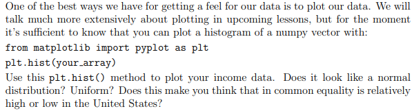

### 3)

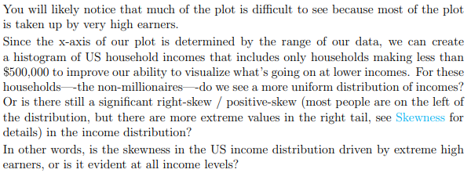

### 4)

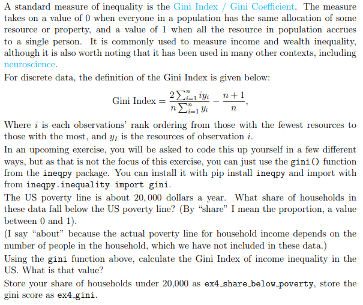

### 5)

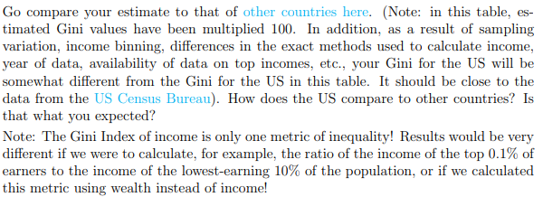

### 6)

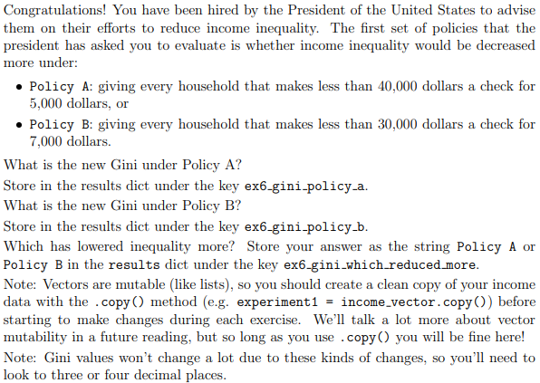

### 7)

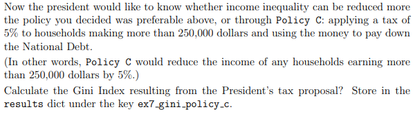

### 8)

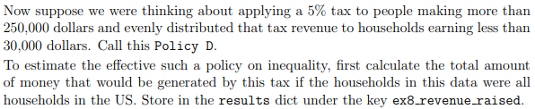

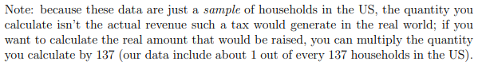

### 9)

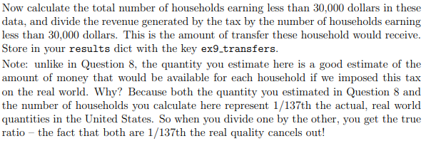

### 10)

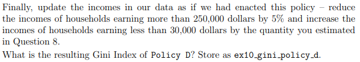

### 11)

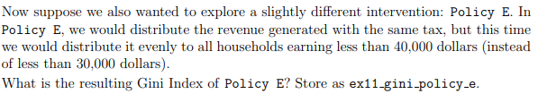